# Lab 3 - Homework

Kyle Landolt

Saturday, February 28, 2015

1. For the first three diagnostic plots, describe wich assumptions they help to visually evaluate.

```
The first step to view the three diagnostic plots is to import libraries and format data. I initally plotted "water year precipitation to rwi" to compare the diagnostic plots to.
```

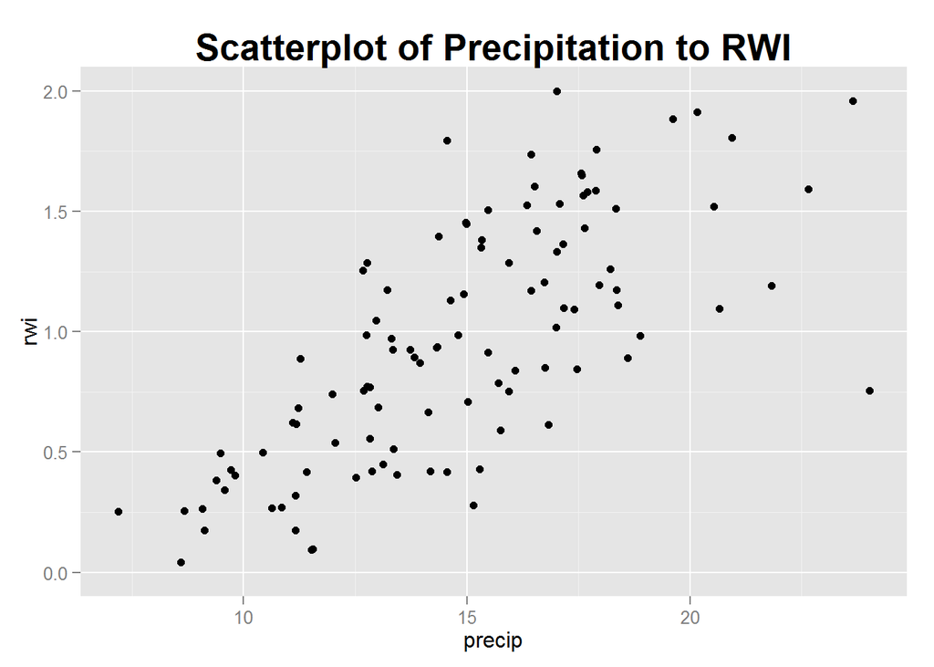

```r
setwd("C:/Users/Kyle/Documents/GEOG415/klandolt/homework3")
library(ggplot2)
library(dplyr)
library(tidyr)
library(magrittr)

precip <- read.csv('data/precip.csv')
rwi <- read.csv('data/rwi.csv')
precip.df <- precip %>% gather(key=month, value=precip, -year) %>% arrange(year, month)
precip.df <- precip.df %>% mutate(water_year = lead(year, 6))
annual_precip <- precip.df %>% group_by(water_year) %>%
   summarize(precip=sum(precip)) %>%
   filter(water_year>1895)
rwi.precip.df <- left_join(rwi, annual_precip, by=c('year'='water_year'))
modelexclude <- lm(rwi~precip, data=rwi.precip.df, na.action=na.exclude)
rwi.precip.df$resid <- residuals(modelexclude)
model <- lm(rwi~precip, data=rwi.precip.df)
ggplot(data=rwi.precip.df) + geom_point(aes(x=precip, y=rwi)) + ylim(c(0, 2)) + ggtitle("Scatterplot of Precipitation to RWI") + theme(plot.title=element_text(lineheight=4, face="bold", size=20))
```

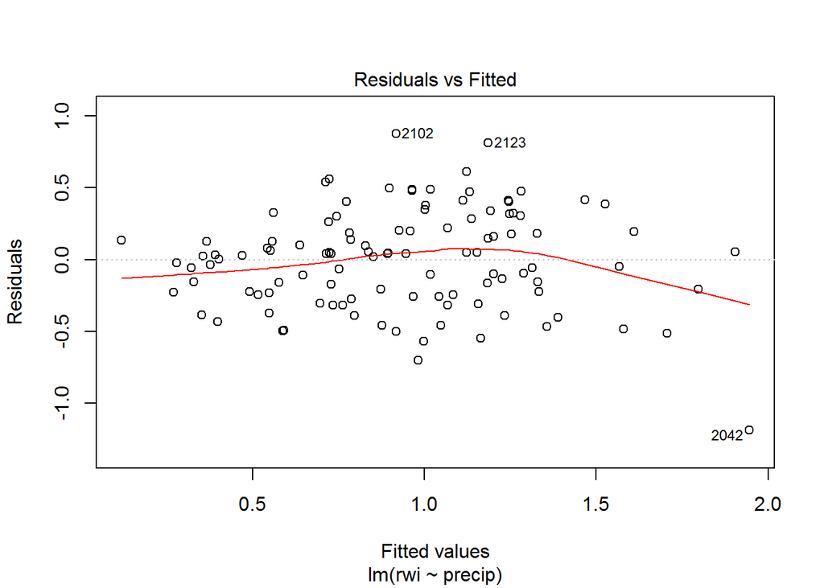

[output not shown]

```r
plot(model, which=1)
```

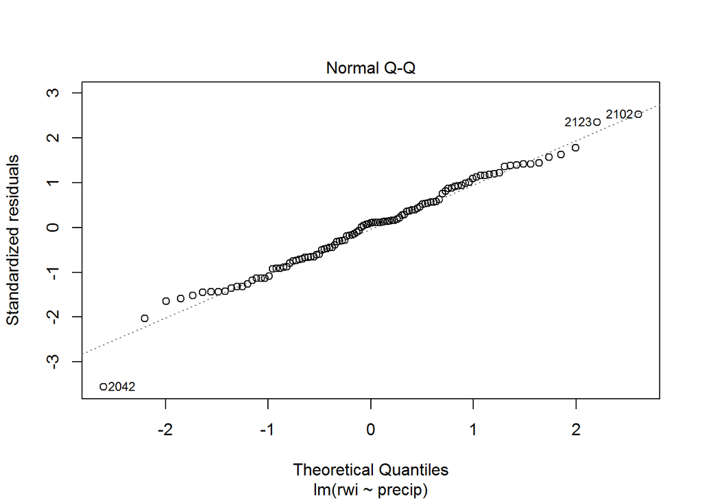

```
Diagnostic Plot 2. Normal Q-Q

The Normal Q-Q plot is fitting the normal curve to residuals. If the plotted points fall along the dotted line of y=x, then the relationship are the distributions are normal. If the plotted points skew off the y=x line, then the distributions of the points aren't normal.
```

```r
plot(model, which=2)
```

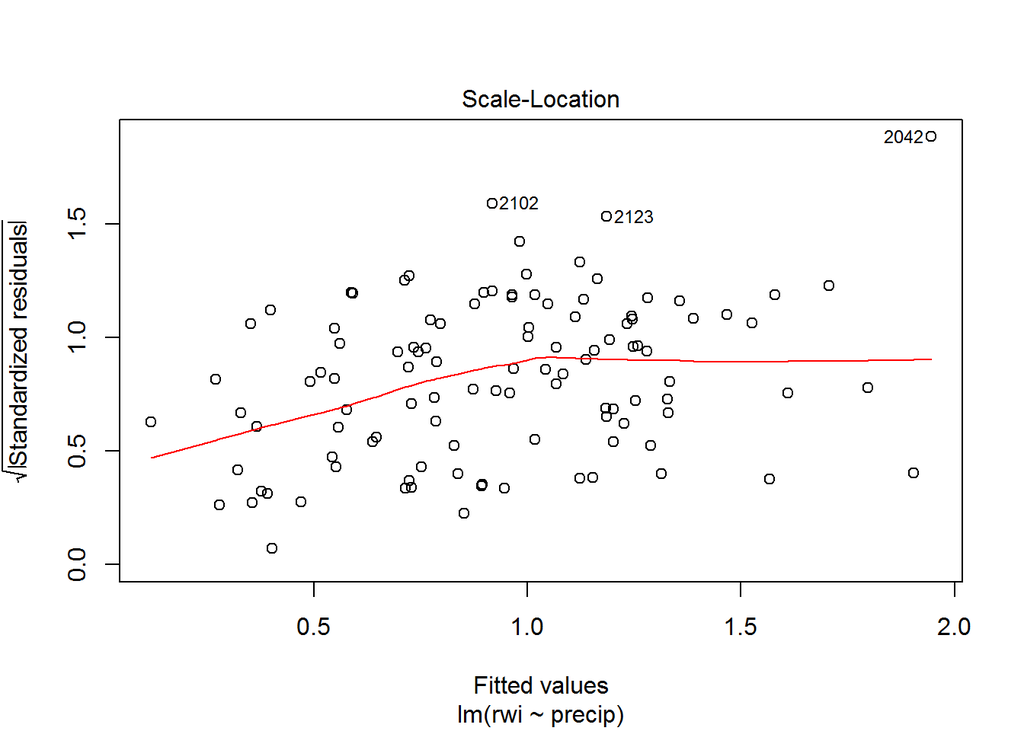

```
Diagnostic Plot 3. Scale-Location

The Scale-Location plot takes the sqrt of the standardized residuals on the y-axis and the regression line dimension on the x-axis. The mean values are represented by a solid red line. The line shows the increasing heteroschedasiticy of the data as the fitted values increase, then slopes off.
```

```r
plot(model, which=3)
```

2. These data are time series data. In general, data are correlated in time, and this would be a problem for simple linear regression. Plot the regression residuals vs time, and visually assess whether there is evidence of temporal (serial) correlation.

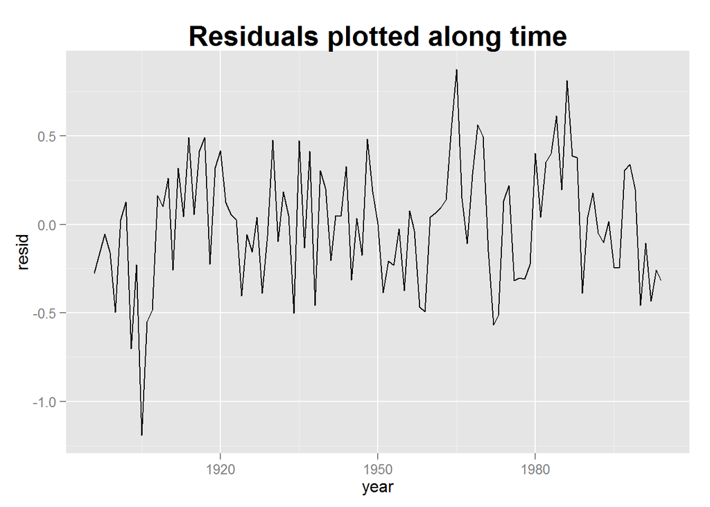

```r
rwi.precip.df.sub <- subset(rwi.precip.df, precip>0)
ggplot(data=rwi.precip.df.sub) + geom_line(aes(x=year, y=resid)) + ggtitle("Residuals plotted along time") + theme(plot.title=element_text(lineheight=4, face="bold", size=20))
```

```r
timeandresid <-  lm(resid~year, data=rwi.precip.df)
summary(timeandresid)
```

```
##
## Call:
## lm(formula = resid ~ year, data = rwi.precip.df)
##
## Residuals:
##      Min       1Q   Median       3Q      Max
## -1.12882 -0.23484  0.02798  0.21917  0.85628
##
## Coefficients:
##              Estimate Std. Error t value Pr(>|t|)
## (Intercept) -2.633131   2.048766  -1.285    0.201
## year         0.001350   0.001051   1.285    0.201
##
## Residual standard error: 0.3451 on 107 degrees of freedom
##   (2032 observations deleted due to missingness)
## Multiple R-squared:  0.01521,    Adjusted R-squared:  0.006003
## F-statistic: 1.652 on 1 and 107 DF,  p-value: 0.2014
```

[output not shown]

3. In the data folder is the dataset GalapagosData.txt. The species data represents the number of species recorded from each of the Galapagos islands. A fundamental ‘law’ of island biogeography is that species diversity tends to follow a power law relationship with island area, i.e. $\mbox{species} = \alpha\times{\mbox{area}^\beta}$  
   This is not linear, but it suggests that the following regression might make sense: $\log(\mbox{species}) = a + \beta \times log(\mbox{area})$ $a$ is not quite $\alpha$, rather $a=\log(\alpha)$.  
   Fit this regression, and present a brief write-up that a) describes the results in words, and b) summarizes your conclusions from diagnostic model checking.

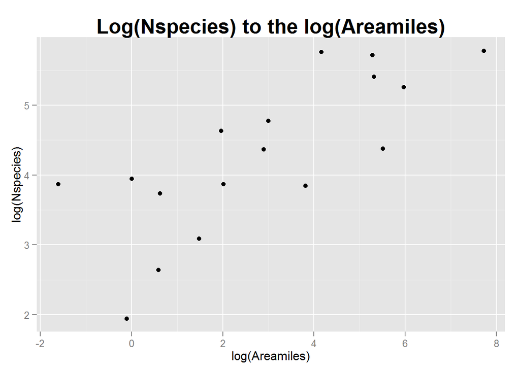

[output not shown]

```r
GalapagosData <- read.table("C:/Users/Kyle/Dropbox/GEOG415/klandolt/homework3/data/GalapagosData.txt", header=TRUE, quote="\"")
#GalapagosData <- read.table("~/Dropbox/GEOG415/klandolt/homework3/data/GalapagosData.txt", header=TRUE, quote="\"")
gala <- GalapagosData
ggplot(data=gala) + geom_point(aes(x=log(Areamiles), y=log(Nspecies))) + ggtitle("Log(Nspecies) to the log(Areamiles)") + theme(plot.title=element_text(lineheight=4, face="bold", size=20))
```

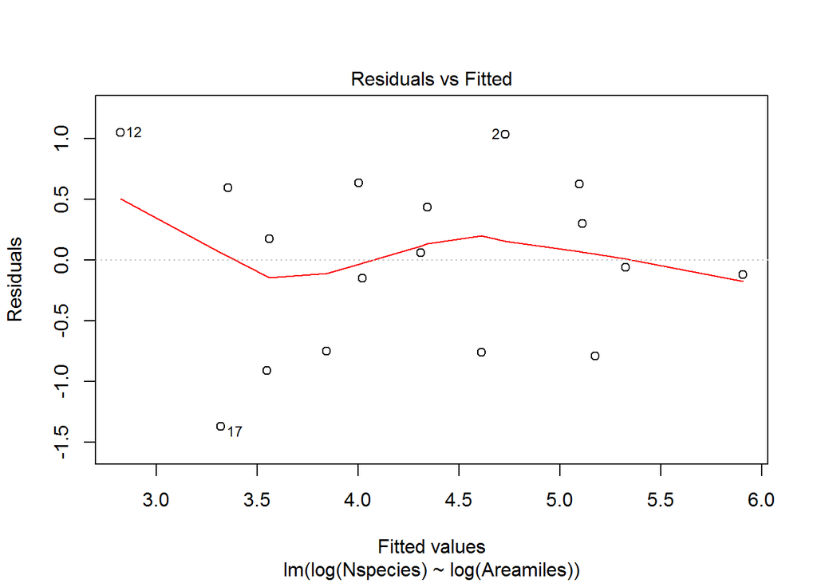

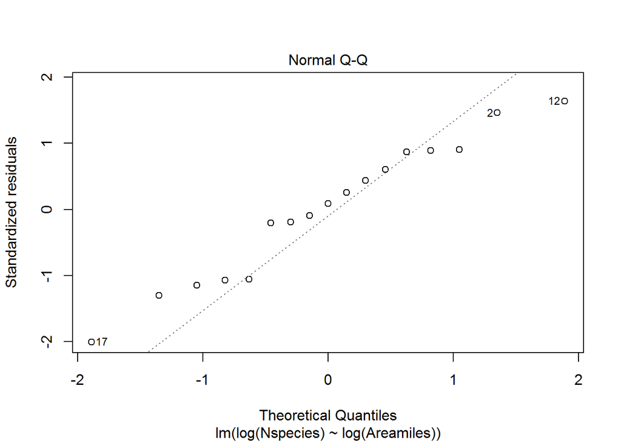

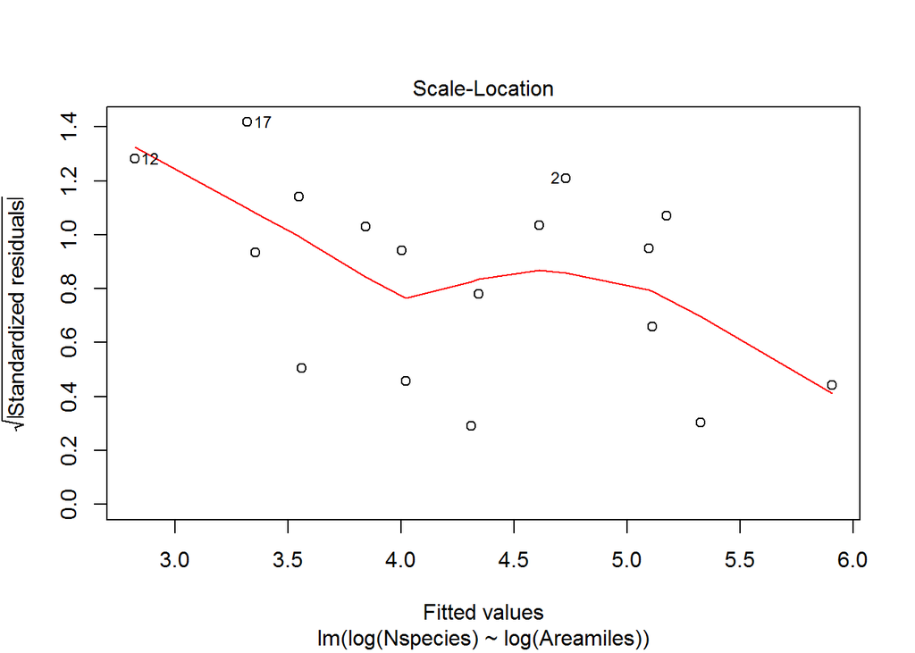

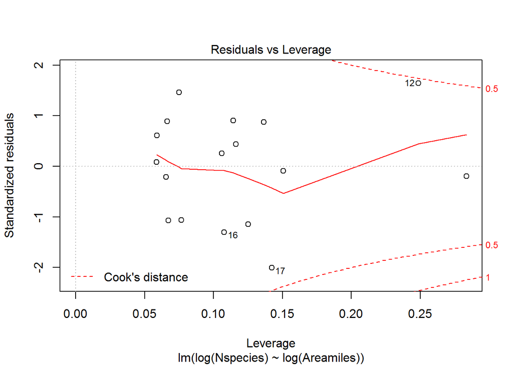

```r
galamodel <- lm(log(Nspecies)~log(Areamiles), data=gala)
plot(galamodel)
```

```r
summary(galamodel)
```

```
##
## Call:
## lm(formula = log(Nspecies) ~ log(Areamiles), data = gala)
##
## Residuals:
##      Min       1Q   Median       3Q      Max
## -1.37282 -0.75233  0.06034  0.59768  1.04971
##
## Coefficients:
##                Estimate Std. Error t value Pr(>|t|)
## (Intercept)     3.35357    0.27254  12.305 3.07e-09 ***
## log(Areamiles)  0.33059    0.07194   4.595  0.00035 ***
## ---
## Signif. codes:  0 '***' 0.001 '**' 0.01 '*' 0.05 '.' 0.1 ' ' 1
##
## Residual standard error: 0.7378 on 15 degrees of freedom
## Multiple R-squared:  0.5847, Adjusted R-squared:  0.557
## F-statistic: 21.12 on 1 and 15 DF,  p-value: 0.0003501
```

[output not shown]